# Análisis del desempeño futbolístico en 5 ligas europeas entre 2014 y 2020

# 7. Modelos de Variables Aleatorias

[output not shown]

# 8. Análisis inferencial

## 8.1 Prueba de Hipótesis e intervalos de confianza

### Hipótesis 1

$H_0:$ La media del minuto en que se realiza un disparo en un partido de futbol de alguna de las 5 grandes ligas europeas como máximo 45.  
$H_0:$ $\mu \le 45$  
$H_1:$ La media del minuto en que se realiza un disparo en un partido de futbol de alguna de las 5 grandes ligas europeas es mayor a 45.  
$H_1:$ $\mu > 45$

Intervalo de confianza al 90% para la media del minuto en que se realiza un disparo.

```
## [1] 48.37333
```

```
## [1] 51.10467
```

Intervalo de confianza al 90% para la varianza del minuto en que se realiza un disparo.

```
## [1] 640.2269
```

```
## [1] 734.8563
```

Intervalo de confianza al 90% para la desviacion estándar del minuto en que se realiza un disparo

```
## [1] 25.3027
```

```
## [1] 27.236
```

Prueba de hipótesis unilateral con cola hacia la derecha:

```
##
##  One Sample t-test
##
## data:  disparos_sam
## t = 5.7131, df = 999, p-value = 7.315e-09
## alternative hypothesis: true mean is greater than 45
## 90 percent confidence interval:
##  48.67526      Inf
## sample estimates:
## mean of x
##    49.739
```

Dado que el p-value es menor a nuestra significancia se rechaza la hipótesis nula, es decir, podemos aceptar que al 90% la media es mayor a 45.

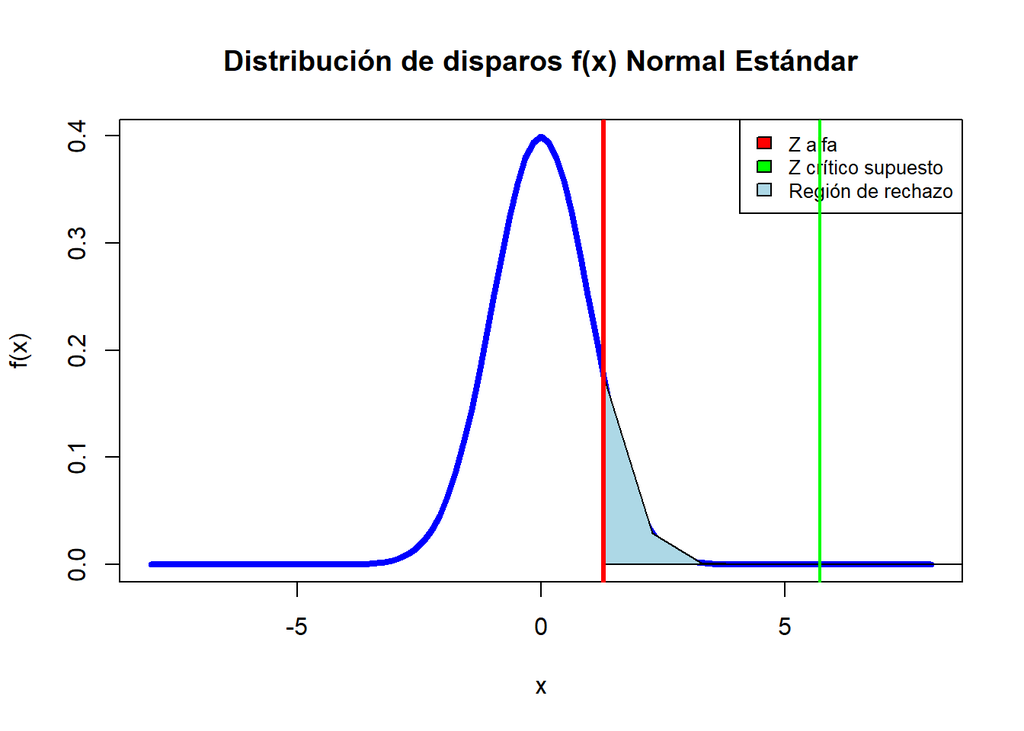

A partir de esta gráfica, habiendo calculado los valores para $t_c$ y $t_0$ podemos notar que nos encontramos en la región de rechazo para una hipótesis unilateral con cola hacia la derecha, por lo que se comprueba que nuestra hipótesis nula es rechazada.

### Hipótesis 2

$H_0:$ La media de las victorias por equipos de la Bundesliga es menor o igual al de la Serie A  
$H_0:$ $\mu \le 66.4$  
$H_1:$ La media de las victorias por equipos de la Bundesliga es es mayor al de la Serie A  
$H_1:$ $\mu > 66.4$

Intervalo de confianza al 85% para la media de victorias por equipos de la Bundesliga.

```
## [1] 51.41556
```

```
## [1] 77.38444
```

Intervalo de confianza al 85% para la varianza de victorias por equipos de la Bundesliga.

```
## [1] 1323.026
```

```
## [1] 3079.613
```

Intervalo de confianza al 85% para la desviación estándar de victorias por equipos de la Bundesliga.

```
## [1] 36.37342
```

```
## [1] 55.49426
```

Prueba de hipótesis unilateral con cola hacia la derecha:

```
##
##  One Sample t-test
##
## data:  aux_v$V
## t = -0.22906, df = 24, p-value = 0.5896
## alternative hypothesis: true mean is greater than 66.4
## 85 percent confidence interval:
##  55.15091      Inf
## sample estimates:
## mean of x
##      64.4
```

Dado que el p-value es mayor a nuestra significancia se acepta nuestra hipótesis nula y podemos decir que la media es menor o igual a 66.4 al 85% de confianza.

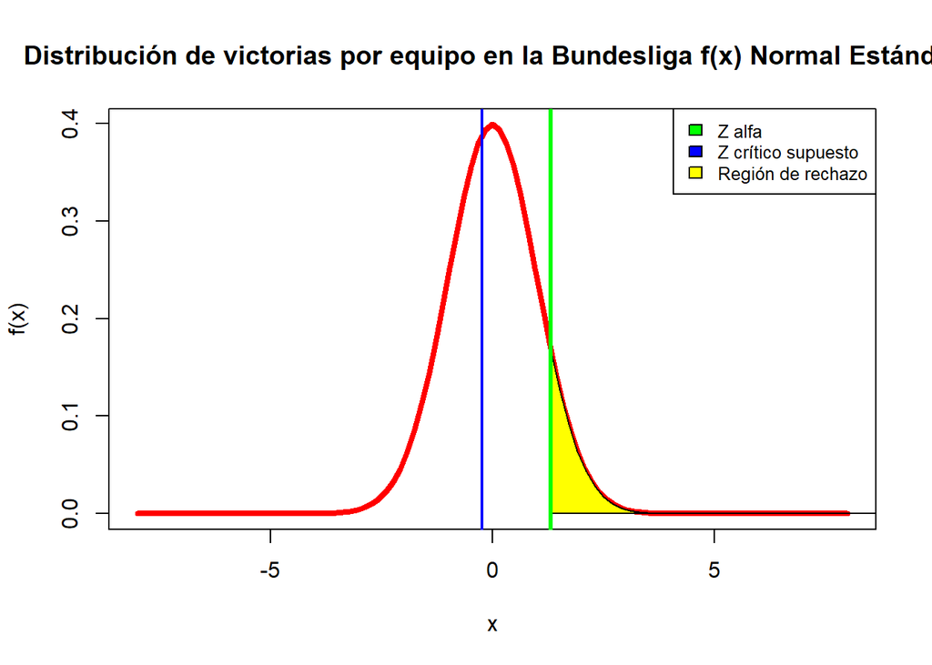

A partir de esta gráfica, habiendo calculado los valores para $t_c$ y $t_o$ podemos notar que nos encontramos en la región de aceptación de la hipótesis nula, por lo que se comprueba que al 85% nuestra media es menor que 66.4.

### Hipótesis 3

$H_0:$ La media de las faltas por partido por equipo de la Serie A es menor o igual a 14  
$H_0:$ $\mu \le 14$  
$H_1:$ La media de las faltas por partido por equipo de la serie A es mayor a 14  
$H_1:$ $\mu > 14$

Intervalo de confianza al 90% para la media de faltas por partido por equipo en la Serie A.

```
## [1] 13.85708
```

```
## [1] 14.04968
```

Intervalo de confianza al 90% para la varianza de faltas por partido por equipo en la Serie A.

```
## [1] 17.66162
```

```
## [1] 18.82508
```

Intervalo de confianza al 90% para la desviación estándar de faltas por partido por equipo en la Serie A.

```
## [1] 4.202573
```

```
## [1] 4.338788
```

Prueba de hipótesis unilateral con cola hacia la derecha:

```
##
##  One Sample t-test
##
## data:  aux_faltas$fouls
## t = -0.79638, df = 5319, p-value = 0.7871
## alternative hypothesis: true mean is greater than 14
## 90 percent confidence interval:
##  13.87836      Inf
## sample estimates:
## mean of x
##  13.95338
```

Dado que el p-value es mayor que nuestra significancia se acepta nuestra hipótesis nula, por lo que podemos aceptar que al 90% la media es menor a 14.

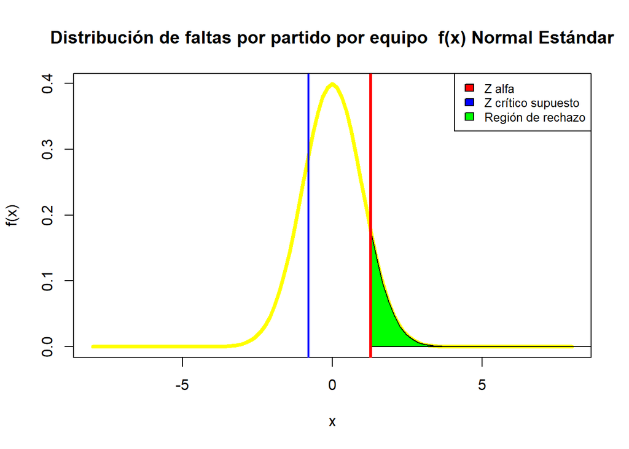

A partir de esta gráfica, habiendo calculado los valores para $t_c$ y $t_0$ podemos notar que nos encontramos en la región de aceptación para una hipótesis unilateral con cola hacia la derecha, por lo que se comprueba que al 90% la media es menor a 14.

# 9.Relaciones entre variables y regresión

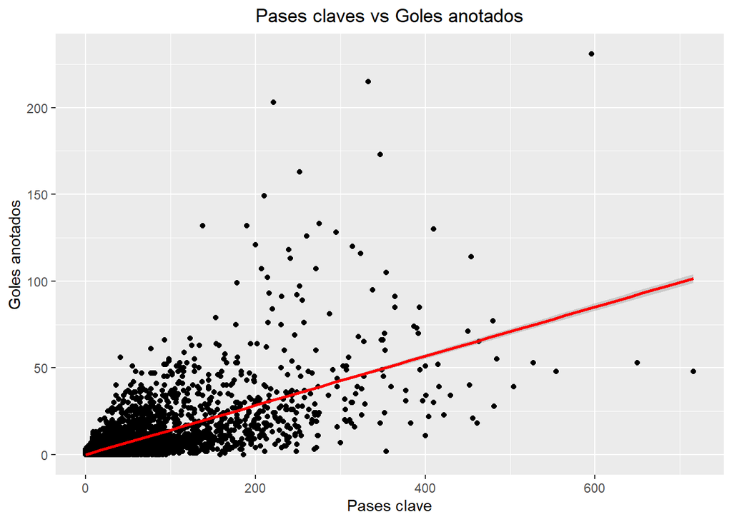

```
##             (Intercept) pases_tabla$total_pases
##              0.08293506              0.14176047
```

La siguiente ecuación describe la función lineal obtenida del gráfico de correlación goles anotados vs pases claves.

$$\begin{equation}
f(x)= 0.0829 + 0.1418x
\end{equation}$$

Se puede ver que la correlación entre los goles anotados y los pases clave es regular (0.69), esto se debe principalmente a que no todos los goles anotados van a ser siempre a razón de un pase clave, puede deberse a otro tipo de variables como asistencias, tiros libres y penales. De todas formas, como se mencionó anteriormente, un pase clave arma un ataque ofensivo con objetivos de gol por lo que su relación con los goles anotados tampoco es nula.

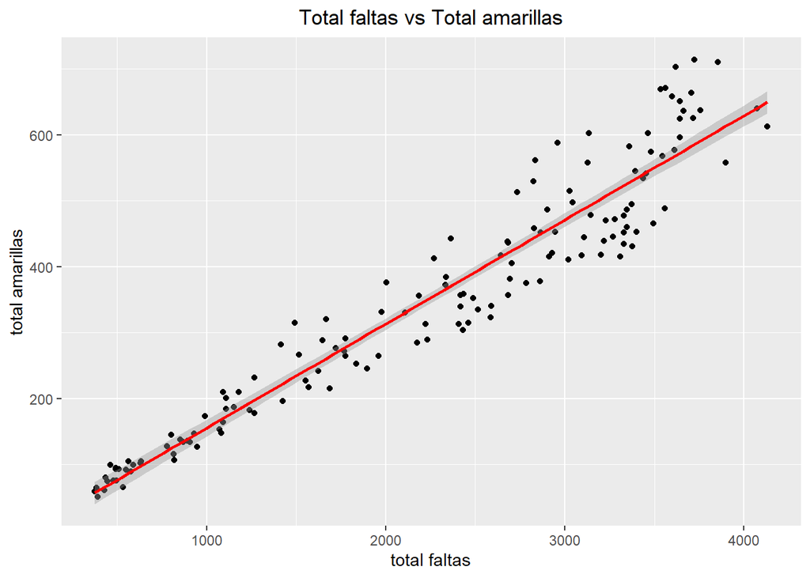

```
##        (Intercept) total$total_faltas
##         -2.2933093          0.1577502
```

La siguiente ecuación describe la función lineal obtenida del gráfico de correlación total de amarillas vs total de faltas.

$$\begin{equation}
f(x)= -2.2933 + 0.1578x
\end{equation}$$

El coeficiente de correlación de ambas variables es 0.96. El valor elevado de este coeficiente se debe, principalmente, a que cuando un jugador comete varias entradas agresivas o faltas leves en el mismo partido es muy probable que termine con una tarjeta amarilla al final de este.

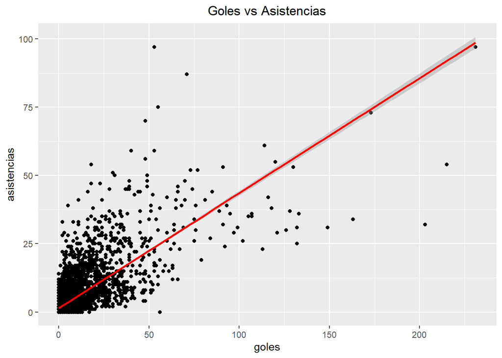

```
##     (Intercept) patrones3$goles
##       1.4724022       0.4206835
```

El modelo lineal que relaciona la variable goles anotados y asistencias realizadas se representa por la siguiente ecuación:

$$\begin{equation}
f(x)= 1.4724 + 0.4207x
\end{equation}$$

La correlación entre las dos variables es de 0.74, es decir, una correlación positiva alta. La interpretación que le damos a esta gráfica es que existe una tendencia a que los jugadores que más involucrados están con el ataque, como extremos o segundos delanteros, tienden a hacerlo tanto a través de goles como asistencias. Por otro lado, también existen mediocampistas ofensivos, cuyo rol se centra en las asistencias pero no los priva de la anotación de goles. Se podría plantear como hipótesis que los jugadores que más goles anoten en las siguientes temporadas tendrán también una considerable cantidad de asistencias debido a su influencia ofensiva.

## 9.1 Predicciones en base a los modelos de variables

Como predicción, para esta tendencia entre equipos, se toma como ejemplo al club Juventus, el cual tiene un total de 3453 faltas acumuladas y un total de $541$ tarjetas amarillas. Reemplazando en el modelo lineal planteado de $f(x)=-2.2933+0.1578x$ con un valor de $x=3453$ se tiene un valor de $f(3453)=542.6$, valor extremadamente cercano al valor real de tarjetas amarillas del Juventus. Esto confirma, junto con la tendencia uniforme visible en el gráfico, que nuestro modelo es preciso para predecir tarjetas amarillas a partir del número de faltas.

# 10. Conclusiones y reflexión

Entre las preguntas planteadas:

## Faltas

Se planteó determinar la liga con más faltas y amarillas y, efectivamente, pudimos encontrar que la Serie A es la liga con más faltas acumuladas con 74 232. Asimismo, es muy probable que, al tener más faltas, es la que haya tenido más tarjetas amarillas. A simple razonamiento, la acumulación de faltas lleva mayormente a amarillas. De este modo, logramos modelar una función lineal para este evento: $f(x)=-2.2933+0.1578x$. De igual manera, con más detalle, se logró realizar una prueba de hipótesis para la liga con más faltas acumuladas, Serie A. En esta prueba unilateral con NC al 90% se analiza la media de faltas por partido por equipo de la liga Serie A y se concluye que la media de faltas por partido es menor a 14, la cual sería de 13.95.

## Análisis: Messi, “el bicho” Cristiano Ronaldo y nuevas estrellas del fútbol

En el periodo 2014-2020 existen dos jugadores que sobresalen con respecto a los demás, los cuales son Lionel Messi y Cristiano Ronaldo. Ambos delanteros aparecen en los primeros lugares de las estadísticas de cantidad de goles, promedio goleador y disparos. Por un lado, Ronaldo es el jugador con más disparos al arco y con un promedio goleador prácticamente igual al de Messi, mientras que el jugador argentino también figura en el podio de estadísticas como asistencias y pases clave. De este modo, podríamos clasificar a un Cristiano como un jugador de perfil goleador, mientras que Messi despliega su faceta ofensiva de un modo más completo. Además, notamos la presencia de dos jugadores jóvenes que comienzan a escalar posiciones en las estadísticas goleadores, los cuales son Erling Haaland y Kylian Mbappé. Ambas promesas del fútbol mundial ya cuentan con números lo suficientemente importantes como para estar a la par de jugadores con trayectorias mucho más extensas.